title: “R Notebook”

output:

html_document:

```
df_print: paged
```

html_notebook: default

pdf_document: default

word_document: default

*Модели*: множественная линейная регрессия, kNN.

Цель: исследовать набор данных `Boston` с помощью линейной регрессионной модели. Задействовав все возможные регрессоры, сделать вывод о пригодности модели для прогноза. Сравнить с методом k ближайших соседей по MSE на тестовой выборке.

```r
# загрузка пакетов

library('GGally')       # графики совместного разброса переменных

library('lmtest')       # тесты остатков регрессионных моделей

library('FNN')          # алгоритм kNN

library('MASS')

# константы

my.seed <- 12345

train.percent <- 0.85



# загрузка данных

data(Boston)


# преобразуем категориальную переменную в фактор

Boston$chas <- as.factor(Boston$chas)



# обучающая выборка

set.seed(my.seed)

bost <- Boston[, -c(2,5,6,7,8,9,11,13,14)]

inTrain <- sample(seq_along(bost$crim),

                  nrow(bost) * train.percent)

df.train <- bost[inTrain, c(colnames(bost)[-1], colnames(bost)[1])]

df.test <- bost[-inTrain, -1]
```

## Описание переменных

Набор данных `Boston` содержит переменные:

- `crime` – уровень преступности на душу населения города;
- `chas` – Фиктивная переменная реки Чарльз (**1**, Если тракт ограничивает реку; **0** в противном случае);
- `tax` – полная стоимость имущества-ставка налога за $10,000;
- `indus` - доля не-розничных акров бизнеса в городе;
- `black` – 1000 (Bk - 0.63)^2, где Bk-доля чернокожих по городам.

Размерность обучающей выборки: $n = 430$ строк, $p = 4$ объясняющих переменных. Зависимая переменная – `crim`.

```r
# описательные статистики по переменным

summary(df.train)
```

```
##      indus       chas         tax          black             crim
##  Min.   : 0.46   0:400   Min.   :187   Min.   :  0.32   Min.   : 0.00632
##  1st Qu.: 5.13   1: 30   1st Qu.:279   1st Qu.:376.06   1st Qu.: 0.08204
##  Median : 8.56           Median :330   Median :391.38   Median : 0.25278
##  Mean   :10.89           Mean   :403   Mean   :358.18   Mean   : 3.21937
##  3rd Qu.:18.10           3rd Qu.:666   3rd Qu.:396.23   3rd Qu.: 3.43597
##  Max.   :27.74           Max.   :711   Max.   :396.90   Max.   :51.13580
```

## Модели

```r
model.1 <- lm(crim ~ . + chas:tax + chas:black + chas:indus,

              data = df.train)

summary(model.1)
```

```
##
## Call:
## lm(formula = crim ~ . + chas:tax + chas:black + chas:indus, data = df.train)
##
## Residuals:
##     Min      1Q  Median      3Q     Max
## -10.803  -2.055  -0.067   0.848  35.961
##
## Coefficients:
##              Estimate Std. Error t value Pr(>|t|)
## (Intercept) -1.284816   1.473024  -0.872    0.384
## indus       -0.014438   0.049597  -0.291    0.771
## chas1       -0.842351   7.331815  -0.115    0.909
## tax          0.025166   0.002120  11.873  < 2e-16 ***
## black       -0.015175   0.002943  -5.156 3.88e-07 ***
## chas1:tax   -0.009681   0.008309  -1.165    0.245
## chas1:black  0.011548   0.016872   0.684    0.494
## indus:chas1 -0.030715   0.232365  -0.132    0.895
## ---
## Signif. codes:  0 '***' 0.001 '**' 0.01 '*' 0.05 '.' 0.1 ' ' 1
##
## Residual standard error: 4.714 on 422 degrees of freedom
## Multiple R-squared:  0.508,  Adjusted R-squared:  0.4998
## F-statistic: 62.25 on 7 and 422 DF,  p-value: < 2.2e-16
```

Взаимодействие `chas:tax` исключаем оно не значимо

```r
summary(model.1)
```

```
##
## Call:
## lm(formula = crim ~ . + chas:tax + chas:black + chas:indus, data = df.train)
##
## Residuals:
##     Min      1Q  Median      3Q     Max
## -10.803  -2.055  -0.067   0.848  35.961
##
## Coefficients:
##              Estimate Std. Error t value Pr(>|t|)
## (Intercept) -1.284816   1.473024  -0.872    0.384
## indus       -0.014438   0.049597  -0.291    0.771
## chas1       -0.842351   7.331815  -0.115    0.909
## tax          0.025166   0.002120  11.873  < 2e-16 ***
## black       -0.015175   0.002943  -5.156 3.88e-07 ***
## chas1:tax   -0.009681   0.008309  -1.165    0.245
## chas1:black  0.011548   0.016872   0.684    0.494
## indus:chas1 -0.030715   0.232365  -0.132    0.895
## ---
## Signif. codes:  0 '***' 0.001 '**' 0.01 '*' 0.05 '.' 0.1 ' ' 1
##
## Residual standard error: 4.714 on 422 degrees of freedom
## Multiple R-squared:  0.508,  Adjusted R-squared:  0.4998
## F-statistic: 62.25 on 7 and 422 DF,  p-value: < 2.2e-16
```

```r
model.2 <- lm(crim ~ . + chas:black + chas:indus,

              data = df.train)

summary(model.2)
```

```
##
## Call:
## lm(formula = crim ~ . + chas:black + chas:indus, data = df.train)
##
## Residuals:
##     Min      1Q  Median      3Q     Max
## -10.780  -2.101  -0.026   1.011  35.967
##
## Coefficients:
##              Estimate Std. Error t value Pr(>|t|)
## (Intercept) -1.047107   1.459442  -0.717    0.473
## indus       -0.004672   0.048904  -0.096    0.924
## chas1       -1.229305   7.327382  -0.168    0.867
## tax          0.024536   0.002050  11.966  < 2e-16 ***
## black       -0.015421   0.002937  -5.251  2.4e-07 ***
## chas1:black  0.009236   0.016762   0.551    0.582
## indus:chas1 -0.222419   0.164140  -1.355    0.176
## ---
## Signif. codes:  0 '***' 0.001 '**' 0.01 '*' 0.05 '.' 0.1 ' ' 1
##
## Residual standard error: 4.716 on 423 degrees of freedom
## Multiple R-squared:  0.5064, Adjusted R-squared:  0.4994
## F-statistic: 72.34 on 6 and 423 DF,  p-value: < 2.2e-16
```

Взаимодействие `chas:black` исключаем

```r
model.3 <- lm(crim ~ . + chas:indus,

              data = df.train)

summary(model.3)
```

```
##
## Call:
## lm(formula = crim ~ . + chas:indus, data = df.train)
##
## Residuals:
##     Min      1Q  Median      3Q     Max
## -10.801  -2.082  -0.032   1.015  36.049
##
## Coefficients:
##              Estimate Std. Error t value Pr(>|t|)
## (Intercept) -1.189606   1.435164  -0.829    0.408
## indus       -0.004841   0.048863  -0.099    0.921
## chas1        2.632080   2.137611   1.231    0.219
## tax          0.024629   0.002042  12.062  < 2e-16 ***
## black       -0.015122   0.002884  -5.244 2.49e-07 ***
## indus:chas1 -0.256533   0.151890  -1.689    0.092 .
## ---
## Signif. codes:  0 '***' 0.001 '**' 0.01 '*' 0.05 '.' 0.1 ' ' 1
##
## Residual standard error: 4.712 on 424 degrees of freedom
## Multiple R-squared:  0.5061, Adjusted R-squared:  0.5002
## F-statistic: 86.89 on 5 and 424 DF,  p-value: < 2.2e-16
```

Коэффициент при `indus` имеет наибольшее р-значение, его исключим

```r
model.4 <- lm(crim ~ chas + tax + black + chas:indus,

              data = df.train)

summary(model.4)
```

```
##
## Call:
## lm(formula = crim ~ chas + tax + black + chas:indus, data = df.train)
##
## Residuals:
##     Min      1Q  Median      3Q     Max
## -10.801  -2.082  -0.032   1.015  36.049
##
## Coefficients:
##              Estimate Std. Error t value Pr(>|t|)
## (Intercept) -1.189606   1.435164  -0.829   0.4076
## chas1        2.632080   2.137611   1.231   0.2189
## tax          0.024629   0.002042  12.062  < 2e-16 ***
## black       -0.015122   0.002884  -5.244 2.49e-07 ***
## chas0:indus -0.004841   0.048863  -0.099   0.9211
## chas1:indus -0.261374   0.152515  -1.714   0.0873 .
## ---
## Signif. codes:  0 '***' 0.001 '**' 0.01 '*' 0.05 '.' 0.1 ' ' 1
##
## Residual standard error: 4.712 on 424 degrees of freedom
## Multiple R-squared:  0.5061, Adjusted R-squared:  0.5002
## F-statistic: 86.89 on 5 and 424 DF,  p-value: < 2.2e-16
```

```r
model.5 <- lm(crim ~ tax + black + chas:indus,

              data = df.train)

summary(model.5)
```

```
##
## Call:
## lm(formula = crim ~ tax + black + chas:indus, data = df.train)
##
## Residuals:
##     Min      1Q  Median      3Q     Max
## -10.703  -2.140  -0.081   1.076  36.086
##
## Coefficients:
##              Estimate Std. Error t value Pr(>|t|)
## (Intercept) -1.022064   1.429566  -0.715    0.475
## tax          0.024436   0.002037  11.996  < 2e-16 ***
## black       -0.015157   0.002885  -5.253 2.37e-07 ***
## chas0:indus -0.009036   0.048773  -0.185    0.853
## chas1:indus -0.096080   0.072434  -1.326    0.185
## ---
## Signif. codes:  0 '***' 0.001 '**' 0.01 '*' 0.05 '.' 0.1 ' ' 1
##
## Residual standard error: 4.715 on 425 degrees of freedom
## Multiple R-squared:  0.5043, Adjusted R-squared:  0.4996
## F-statistic: 108.1 on 4 and 425 DF,  p-value: < 2.2e-16
```

Взаимодействие `chas:indus` исключаем оно не значимо

```r
model.6 <- lm(crim ~ tax + black,

              data = df.train)

summary(model.6)
```

```
##
## Call:
## lm(formula = crim ~ tax + black, data = df.train)
##
## Residuals:
##     Min      1Q  Median      3Q     Max
## -10.669  -2.091  -0.042   0.997  36.169
##
## Coefficients:
##              Estimate Std. Error t value Pr(>|t|)
## (Intercept) -1.031246   1.427648  -0.722     0.47
## tax          0.024081   0.001528  15.763  < 2e-16 ***
## black       -0.015224   0.002871  -5.302 1.84e-07 ***
## ---
## Signif. codes:  0 '***' 0.001 '**' 0.01 '*' 0.05 '.' 0.1 ' ' 1
##
## Residual standard error: 4.715 on 427 degrees of freedom
## Multiple R-squared:  0.5019, Adjusted R-squared:  0.4996
## F-statistic: 215.1 on 2 and 427 DF,  p-value: < 2.2e-16
```

Очевидно, стоит остановиться на модели без взаимодействий. Проверим её остатки.

# Проверка остатков

```r
# тест Бройша-Пагана

bptest(model.6)
```

```
##
##  studentized Breusch-Pagan test
##
## data:  model.6
## BP = 49.349, df = 2, p-value = 1.923e-11
```

```r
# статистика Дарбина-Уотсона

dwtest(model.6)
```

```
##
##  Durbin-Watson test
##
## data:  model.6
## DW = 2.0101, p-value = 0.5411
## alternative hypothesis: true autocorrelation is greater than 0
```

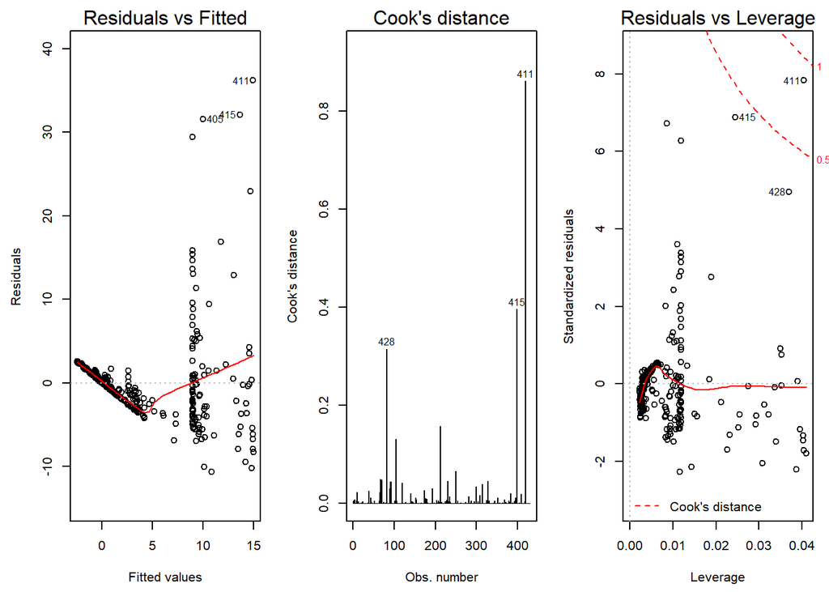

```r
# графики остатков

par(mar = c(4.5, 4.5, 2, 1))

par(mfrow = c(1, 3))

plot(model.6, 1)

plot(model.6, 4)

plot(model.6, 5)
```

```r
par(mfrow = c(1, 1))
```

Судя по графику слева, остатки не случайны, и их дисперсия непостоянна. Графики остатков заставляют усомниться в том, что остатки удовлетворяют условиям Гаусса-Маркова.

# Сравнение с kNN

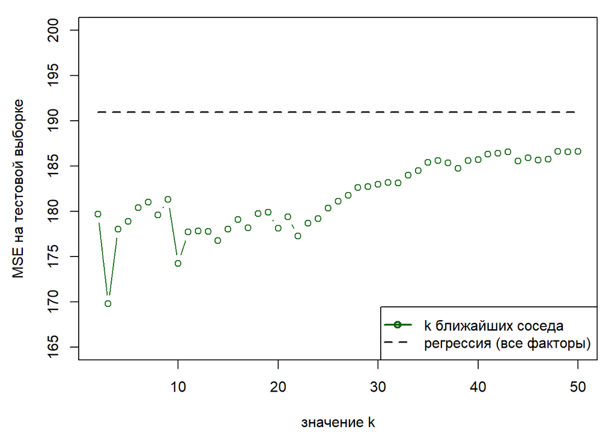

```r
# фактические значения y на тестовой выборке

y.fact <- bost[-inTrain, 1]

y.model.lm <- predict(model.6, df.test)

MSE.lm <- sum((y.model.lm - y.fact)^2) / length(y.model.lm)



# kNN требует на вход только числовые переменные

df.train.num <- as.data.frame(apply(df.train, 2, as.numeric))

df.test.num <- as.data.frame(apply(df.test, 2, as.numeric))



for (i in 2:50){

    model.knn <- knn.reg(train = df.train.num[, !(colnames(df.train.num) %in% 'crim')],

                     y = df.train.num[, 'crim'],

                     test = df.test.num, k = i)

    y.model.knn <- model.knn$pred

    if (i == 2){

        MSE.knn <- sum((y.model.knn - y.fact)^2) / length(y.model.knn)

    } else {

        MSE.knn <- c(MSE.knn,

                     sum((y.model.knn - y.fact)^2) / length(y.model.knn))

    }

}



# график

par(mar = c(4.5, 4.5, 1, 1))

# ошибки kNN

plot(2:50, MSE.knn, type = 'b', col = 'darkgreen',  ylim = c(165, 200),

     xlab = 'значение k', ylab = 'MSE на тестовой выборке')

# ошибка регрессии

lines(2:50, rep(MSE.lm, 49), lwd = 2, col = grey(0.2), lty = 2)

legend('bottomright', lty = c(1, 2), pch = c(1, NA),

       col = c('darkgreen', grey(0.2)),

       legend = c('k ближайших соседа', 'регрессия (все факторы)'),

       lwd = rep(2, 2))
```